# Value-Estimation Analysis

Jiarong Feng

2026-06-03

# Overview

This report focuses on **value-estimation performance**. These are the assessment items where participants estimated either the correlation value or the slope value from a scatterplot.

The add-points tasks are analyzed separately. Here, I keep the correlation and slope estimation analyses separate because they are conceptually different skills and use different prior-knowledge covariates.

The main outcome is absolute error:

> `abs_error_no_extreme = |participant estimate - correct value|`

Lower values mean better performance. Extreme slope entries where `|answer| > 10` were preserved in the raw data but excluded from the primary cleaned error variable.

# Load scored outcome files

The scoring notebook writes the value-estimation outputs to `data/derived/`:

- `scored_value_estimation_item_level.csv`
- `scored_value_estimation_participant_level.csv`
- `participant_outcomes.csv`

Those files are created in `02_parse_and_score_outcomes.Rmd`.

# Data checks

Value-estimation item-level data check

| group | lecture_type | practice_type | stat_type | n_participants | n_item_rows | n_valid_rows | n_extreme_rows |
| --- | --- | --- | --- | --- | --- | --- | --- |
| CC | Control | Control | correlation | 20 | 160 | 160 | 0 |
| CP | Control | PlotWise | correlation | 20 | 160 | 160 | 0 |
| PC | PlotWise | Control | correlation | 20 | 160 | 160 | 0 |
| PP | PlotWise | PlotWise | correlation | 20 | 160 | 160 | 0 |
| CC | Control | Control | slope | 20 | 140 | 134 | 6 |
| CP | Control | PlotWise | slope | 20 | 140 | 130 | 10 |
| PC | PlotWise | Control | slope | 20 | 140 | 140 | 0 |
| PP | PlotWise | PlotWise | slope | 20 | 140 | 138 | 2 |

**Scoring note.** Extreme entries are only expected for slope. The primary error variable excludes those entries, so the slope analysis reflects cleaned value-estimation error rather than a few very large numeric entries.

# Descriptive performance

## Participant-level mean absolute error

Participant-level value-estimation performance by condition

| Statistic type | Condition | Lecture type | Practice type | n participants | Mean absolute error | SD absolute error | Median absolute error | Mean sign-error rate |
| --- | --- | --- | --- | --- | --- | --- | --- | --- |
| Correlation | CC | Control | Control | 20 | 0.336 | 0.159 | 0.321 | 14.4% |
| Correlation | CP | Control | PlotWise | 20 | 0.316 | 0.219 | 0.240 | 11.2% |
| Correlation | PC | PlotWise | Control | 20 | 0.333 | 0.186 | 0.277 | 15.0% |
| Correlation | PP | PlotWise | PlotWise | 20 | 0.290 | 0.158 | 0.270 | 8.1% |
| Slope | CC | Control | Control | 20 | 0.296 | 0.350 | 0.145 | 7.1% |
| Slope | CP | Control | PlotWise | 20 | 0.232 | 0.215 | 0.157 | 2.1% |
| Slope | PC | PlotWise | Control | 20 | 0.363 | 0.641 | 0.231 | 3.6% |
| Slope | PP | PlotWise | PlotWise | 20 | 0.238 | 0.129 | 0.183 | 2.9% |

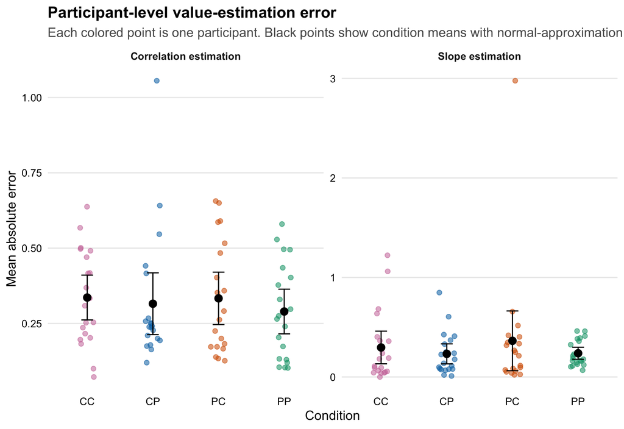

What stands out descriptively. For correlation estimation, PP has the lowest mean error, while CC is highest. The spread is not huge, so I would not treat this as a strong condition effect by itself.

For slope estimation, the lower-error groups are CP and PP, while PC has the highest error. This looks more patterned than correlation descriptively, but the participant-level variation is still important.

## Sign errors

Sign errors by condition

| stat_type | group | n_participants | n_scored_trials | n_sign_errors | sign_error_rate |
| --- | --- | --- | --- | --- | --- |
| Correlation | CC | 20 | 160 | 23 | 14.4% |
| Correlation | CP | 20 | 160 | 18 | 11.2% |
| Correlation | PC | 20 | 160 | 24 | 15.0% |
| Correlation | PP | 20 | 160 | 13 | 8.1% |
| Slope | CC | 20 | 140 | 10 | 7.1% |
| Slope | CP | 20 | 140 | 3 | 2.1% |
| Slope | PC | 20 | 140 | 5 | 3.6% |
| Slope | PP | 20 | 140 | 4 | 2.9% |

**How to read this table.** Here `n_sign_errors` is the count of trials where the participant gave the wrong sign. `n_scored_trials` is the number of nonzero-answer trials used as the denominator.

**Direction mistakes.** Correlation sign errors are more common than slope sign errors. For correlation, **PP** has the lowest sign-error rate ( 8.1% ). For slope, sign errors are low across all conditions.

# Correlation value-estimation model

This model uses only the correlation-estimation items.

**Model formula**

```
abs_error_no_extreme ~ lecture_type * practice_type + (1 | participantId)
```

Model-estimated condition means: correlation absolute error

| Outcome | Condition | Estimated mean | Lower 95% CI | Upper 95% CI |
| --- | --- | --- | --- | --- |
| Correlation absolute error | CC | 0.336 | 0.255 | 0.417 |
| Correlation absolute error | CP | 0.316 | 0.235 | 0.397 |
| Correlation absolute error | PC | 0.333 | 0.252 | 0.414 |
| Correlation absolute error | PP | 0.290 | 0.209 | 0.371 |

Full model results: correlation absolute error

| Term | Estimate | SE | Test statistic | p-value |
| --- | --- | --- | --- | --- |
| Intercept | 0.336 | 0.040 | 8.465 | < .001 |
| PlotWise lecture | -0.003 | 0.056 | -0.049 | 0.961 |
| PlotWise practice | -0.021 | 0.056 | -0.365 | 0.716 |
| PlotWise lecture × PlotWise practice | -0.023 | 0.079 | -0.292 | 0.771 |

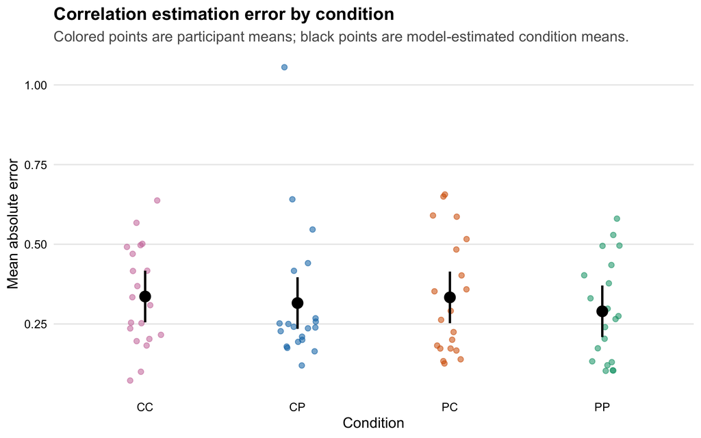

For correlation absolute error, PP has the lowest model-estimated error, while CC has the highest. However, the condition differences are small, and the 95% confidence intervals overlap substantially. The full model also shows no clear lecture effect, practice effect, or lecture × practice interaction. Overall, I would describe this as a weak descriptive trend favoring PP, not evidence of a reliable condition effect for correlation estimation.

# Slope value-estimation model

This model uses only the slope-estimation items. Extreme slope entries are excluded through `abs_error_no_extreme`.

**Model formula**

```
abs_error_no_extreme ~ lecture_type * practice_type + (1 | participantId)
```

Model-estimated condition means: slope absolute error

| Outcome | Condition | Estimated mean | Lower 95% CI | Upper 95% CI |
| --- | --- | --- | --- | --- |
| Slope absolute error | CC | 0.306 | 0.131 | 0.481 |
| Slope absolute error | CP | 0.237 | 0.061 | 0.413 |
| Slope absolute error | PC | 0.363 | 0.191 | 0.535 |
| Slope absolute error | PP | 0.238 | 0.066 | 0.411 |

Full model results: slope absolute error

| Term | Estimate | SE | Test statistic | p-value |
| --- | --- | --- | --- | --- |
| Intercept | 0.306 | 0.086 | 3.573 | < .001 |
| PlotWise lecture | 0.057 | 0.120 | 0.475 | 0.636 |
| PlotWise practice | -0.069 | 0.121 | -0.569 | 0.571 |
| PlotWise lecture × PlotWise practice | -0.056 | 0.170 | -0.326 | 0.745 |

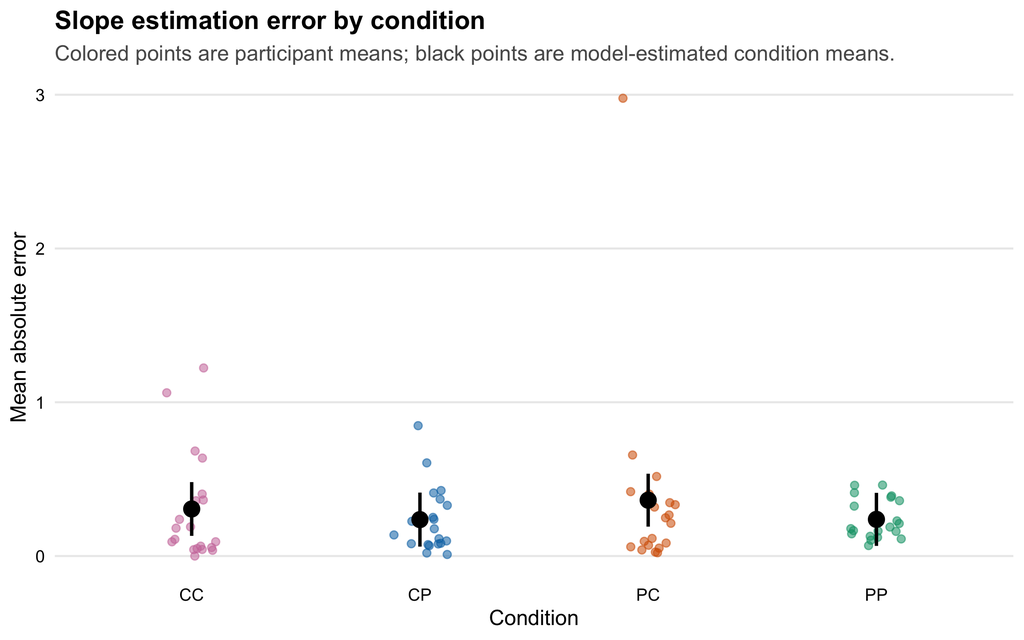

For slope absolute error, CP and PP have the lowest model-estimated errors, while PC has the highest. However, the confidence intervals overlap substantially across all conditions, and the full model shows no clear lecture effect, practice effect, or lecture × practice interaction. I would interpret this as a descriptive pattern suggesting slightly better slope estimation in the PlotWise practice conditions, but not as evidence of a reliable condition effect.

# Condition contrasts

The model coefficients are relative to the reference condition, so I use contrasts to read the condition differences more directly. For value estimation, positive differences mean the first condition has **higher error** than the second condition. Since lower error is better, positive differences favor the second condition.

## Pairwise contrasts

Pairwise comparisons: correlation absolute error

| Outcome | Contrast | Difference | Lower 95% CI | Upper 95% CI | p-value |
| --- | --- | --- | --- | --- | --- |
| Correlation | Control Control - PlotWise Control | 0.003 | -0.148 | 0.154 | 1 |
| Correlation | Control Control - Control PlotWise | 0.021 | -0.130 | 0.172 | 0.984 |
| Correlation | Control Control - PlotWise PlotWise | 0.046 | -0.105 | 0.197 | 0.852 |
| Correlation | PlotWise Control - Control PlotWise | 0.018 | -0.133 | 0.169 | 0.99 |
| Correlation | PlotWise Control - PlotWise PlotWise | 0.044 | -0.107 | 0.195 | 0.873 |
| Correlation | Control PlotWise - PlotWise PlotWise | 0.026 | -0.125 | 0.177 | 0.97 |

Pairwise comparisons: slope absolute error

| Outcome | Contrast | Difference | Lower 95% CI | Upper 95% CI | p-value |
| --- | --- | --- | --- | --- | --- |
| Slope | Control Control - PlotWise Control | -0.057 | -0.381 | 0.266 | 0.967 |
| Slope | Control Control - Control PlotWise | 0.069 | -0.258 | 0.396 | 0.945 |
| Slope | Control Control - PlotWise PlotWise | 0.068 | -0.256 | 0.391 | 0.947 |
| Slope | PlotWise Control - Control PlotWise | 0.126 | -0.198 | 0.450 | 0.737 |
| Slope | PlotWise Control - PlotWise PlotWise | 0.125 | -0.196 | 0.446 | 0.739 |
| Slope | Control PlotWise - PlotWise PlotWise | -0.002 | -0.326 | 0.323 | 1 |

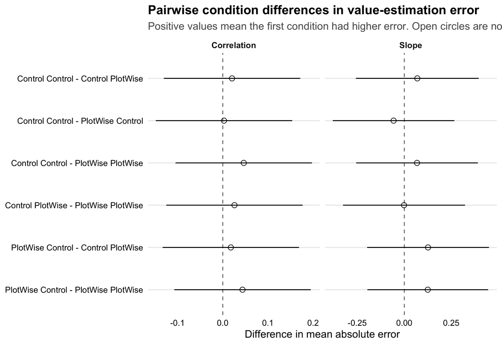

The pairwise contrasts do not show reliable condition differences after Tukey adjustment. For correlation estimation, PP has the lowest estimated error descriptively, but none of the pairwise confidence intervals exclude zero. For slope estimation, PC appears to have higher error than CP and PP, but those differences are also uncertain. Overall, the pairwise results are useful for locating the descriptive pattern, but they do not provide strong evidence that any two conditions differ clearly in value-estimation error.

# Modeling with Prior knowledge

This section asks whether baseline definition knowledge helps explain value-estimation performance.

For the correlation-estimation model, I add the coded correlation-definition score. For the slope-estimation model, I add the coded slope-definition score. Scores are standardized before entering the models.

Loaded prior knowledge scores from `prior_knowledge_coding_sheet_coded.csv` ( long coded sheet ). The coded sheet was converted to participant-level `correlation_score` and `slope_score`. The adjusted models below use standardized prior-knowledge scores.

## Prior knowledge by condition

Prior knowledge scores by condition

| group | lecture_type | practice_type | n | n_with_scores | mean_correlation_prior | sd_correlation_prior | mean_slope_prior | sd_slope_prior | mean_total_prior | sd_total_prior |
| --- | --- | --- | --- | --- | --- | --- | --- | --- | --- | --- |
| CC | Control | Control | 20 | 20 | 0.525 | 0.255 | 0.525 | 0.343 | 1.05 | 0.484 |
| CP | Control | PlotWise | 20 | 20 | 0.550 | 0.276 | 0.550 | 0.456 | 1.10 | 0.661 |
| PC | PlotWise | Control | 20 | 20 | 0.525 | 0.255 | 0.625 | 0.425 | 1.15 | 0.564 |
| PP | PlotWise | PlotWise | 20 | 20 | 0.600 | 0.205 | 0.600 | 0.348 | 1.20 | 0.377 |

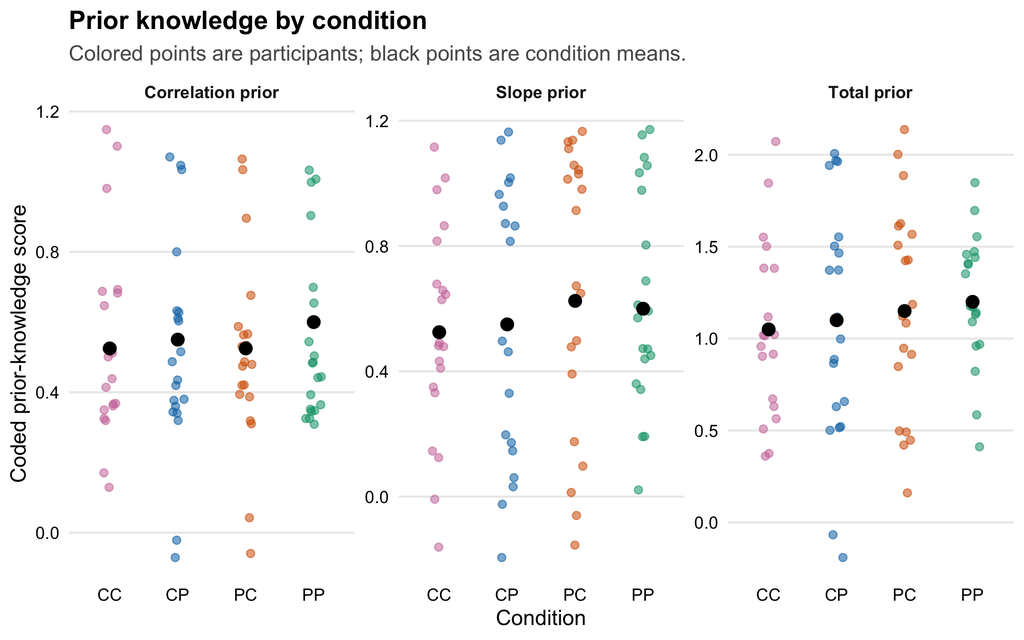

## Correlation model with prior correlation knowledge

**Model formula**

```
abs_error_no_extreme ~ lecture_type * practice_type + correlation_score_z + (1 | participantId)
```

Prior-knowledge-adjusted condition means: correlation absolute error

| Outcome | Condition | Estimated mean | Lower 95% CI | Upper 95% CI |
| --- | --- | --- | --- | --- |
| Correlation absolute error | CC | 0.332 | 0.252 | 0.411 |
| Correlation absolute error | CP | 0.316 | 0.236 | 0.395 |
| Correlation absolute error | PC | 0.329 | 0.250 | 0.409 |
| Correlation absolute error | PP | 0.298 | 0.218 | 0.378 |

Full adjusted model results: correlation absolute error

| Term | Estimate | SE | Test statistic | p-value |
| --- | --- | --- | --- | --- |
| Intercept | 0.332 | 0.039 | 8.575 | < .001 |
| PlotWise lecture | -0.003 | 0.055 | -0.050 | 0.96 |
| PlotWise practice | -0.016 | 0.055 | -0.299 | 0.766 |
| Correlation prior knowledge (standardized) | -0.041 | 0.020 | -2.093 | 0.0395 |
| PlotWise lecture × PlotWise practice | -0.015 | 0.077 | -0.192 | 0.848 |

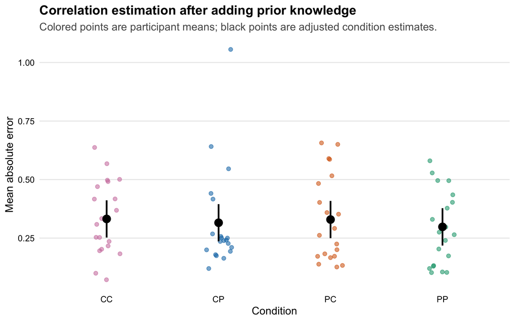

## Slope model with prior slope knowledge

**Model formula**

```
abs_error_no_extreme ~ lecture_type * practice_type + slope_score_z + (1 | participantId)
```

Prior-knowledge-adjusted condition means: slope absolute error

| Outcome | Condition | Estimated mean | Lower 95% CI | Upper 95% CI |
| --- | --- | --- | --- | --- |
| Slope absolute error | CC | 0.291 | 0.121 | 0.460 |
| Slope absolute error | CP | 0.233 | 0.063 | 0.403 |
| Slope absolute error | PC | 0.375 | 0.208 | 0.541 |
| Slope absolute error | PP | 0.243 | 0.077 | 0.410 |

Full adjusted model results: slope absolute error

| Term | Estimate | SE | Test statistic | p-value |
| --- | --- | --- | --- | --- |
| Intercept | 0.293 | 0.082 | 3.556 | < .001 |
| PlotWise lecture | 0.084 | 0.116 | 0.723 | 0.472 |
| PlotWise practice | -0.058 | 0.117 | -0.493 | 0.623 |
| Slope prior knowledge (standardized) | -0.106 | 0.041 | -2.566 | 0.0122 |
| PlotWise lecture × PlotWise practice | -0.074 | 0.164 | -0.451 | 0.653 |

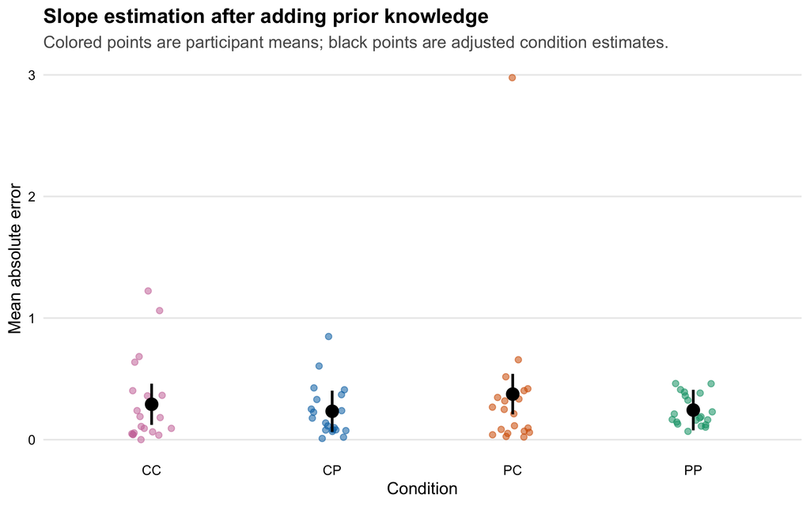

After controlling for participants’ prior knowledge, the condition patterns for value estimation remain small and uncertain. For correlation estimation, PP still has the lowest adjusted error descriptively, but neither lecture, practice, nor the interaction is significant. Prior correlation knowledge is a significant predictor, with higher prior knowledge associated with lower correlation-estimation error.

For slope estimation, CP and PP have the lowest adjusted errors, while PC is highest descriptively. Again, there is no clear lecture, practice, or interaction effect. Prior slope knowledge is a significant predictor, with higher prior slope knowledge associated with lower slope-estimation error. Overall, these models suggest that baseline knowledge explains more variation in value-estimation performance than the experimental conditions.

# Bootstrap uncertainty

The bootstrap resamples participants within each condition. For each bootstrap sample, it recomputes condition mean error and condition differences. This does not create more information; it just gives a nonparametric sense of how stable the observed condition differences are.

## Correlation bootstrap

Bootstrap condition means: correlation absolute error

| Condition | Bootstrap mean error | Lower 95% CI | Upper 95% CI |
| --- | --- | --- | --- |
| CC | 0.335 | 0.268 | 0.403 |
| CP | 0.316 | 0.235 | 0.418 |
| PC | 0.335 | 0.259 | 0.418 |
| PP | 0.289 | 0.224 | 0.360 |

Bootstrap condition differences: correlation absolute error

| Contrast | Mean difference | Lower 95% CI | Upper 95% CI |
| --- | --- | --- | --- |
| CC - CP | 0.020 | -0.100 | 0.127 |
| CC - PC | 0.001 | -0.104 | 0.102 |
| CC - PP | 0.046 | -0.049 | 0.143 |
| CP - PC | -0.019 | -0.138 | 0.108 |
| CP - PP | 0.026 | -0.084 | 0.145 |
| PC - PP | 0.045 | -0.060 | 0.149 |

**Bootstrap read.** For correlation estimation, 6 of the 6 bootstrap difference intervals cross zero. That matches the model results: the PP group looks a little lower-error descriptively, but the group differences are not stable enough to treat as clear condition effects.

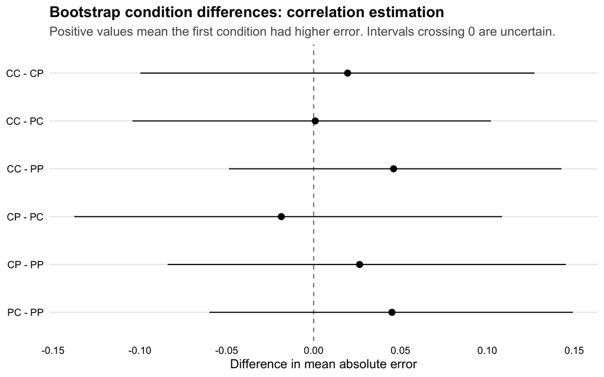

## Slope bootstrap

Bootstrap condition means: slope absolute error

| Condition | Bootstrap mean error | Lower 95% CI | Upper 95% CI |
| --- | --- | --- | --- |
| CC | 0.296 | 0.163 | 0.456 |
| CP | 0.234 | 0.147 | 0.333 |
| PC | 0.363 | 0.167 | 0.691 |
| PP | 0.238 | 0.184 | 0.295 |

Bootstrap condition differences: slope absolute error

| Contrast | Mean difference | Lower 95% CI | Upper 95% CI |
| --- | --- | --- | --- |
| CC - CP | 0.062 | -0.107 | 0.245 |
| CC - PC | -0.068 | -0.432 | 0.203 |
| CC - PP | 0.058 | -0.089 | 0.228 |
| CP - PC | -0.130 | -0.471 | 0.102 |
| CP - PP | -0.004 | -0.107 | 0.109 |
| PC - PP | 0.126 | -0.085 | 0.466 |

**Bootstrap read.** For slope estimation, 6 of the 6 bootstrap difference intervals cross zero. The descriptive pattern points to lower error in the PlotWise-practice groups and higher error in PC, but the bootstrap intervals still leave a lot of uncertainty.

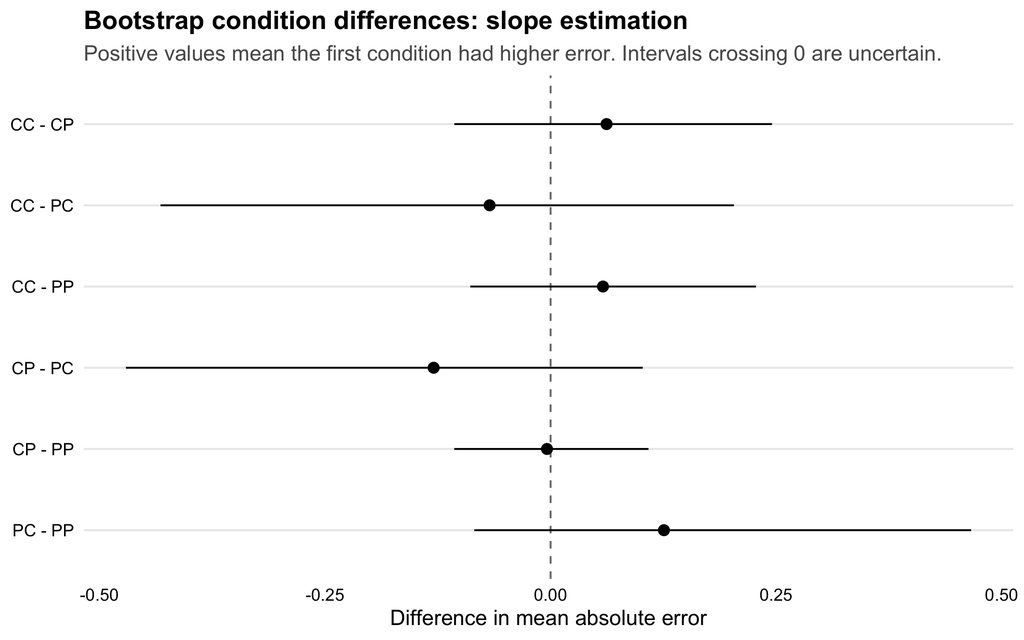

# Summary

For **correlation estimation**, PP is consistently the lowest-error group descriptively, and it also has the lowest sign-error rate. But the differences among conditions are small, the pairwise contrasts are not clear, and the bootstrap intervals for condition differences cross zero. So I would describe this as a descriptive PP advantage, not a strong condition effect.

For **slope estimation**, the pattern is a little more visible: the PlotWise-practice groups have lower estimated error, while PC has the highest error. Still, the uncertainty is wide. This is worth keeping as a pattern to discuss, but I would avoid claiming that the intervention clearly improved slope estimation.

The most reliable result in this report is actually the **prior knowledge adjustment**: better coded correlation definitions predict lower correlation-estimation error, and better coded slope definitions predict lower slope-estimation error. That suggests the definition-coding measure is meaningful and is picking up something related to participants’ later estimation performance.

Overall, value estimation does not show a clean condition effect. The condition patterns are directionally interesting.